# week_7

## Проект "Отток"

## Содержание

1) Техническое задание и исходные данные

2) Цели и задачи проекта

3) Предварительный анализ данных  
3.1) Описательный анализ данных и визуализация  
3.2) Выбор метрики качества и способа ее оценки

4) Построение baseline-решений

5) Построение основного решения

6) Соревнование на Kaggle

7) Эксперименты с моделью прогнозирования и построение финального решения

8) Финальное решение

9) Оценка эффекта от внедрения полученного решения

## 1) Техническое задание и исходные данные:

В 2009 году проводилось соревнование KDD Cup: Customer relationship prediction. В рамках этого соревнования участникам предлагалось решить 3 задачи из области Customer Relationship Management (CRM). В данном проекте необходимо решить задачу:

- оценка вероятности того, что клиент осуществит переход к конкуренту (churn prediction);

Данные для соревнования были предоставлены французской телекоммуникационной компанией Orange. В задаче речь идет о клиентских данных, поэтому данные были предварительно обфусцированы и анонимизированны: из датасета убрана любая персональная информация, позволяющая идентифицировать пользователей, а также не представлены названия и описания переменных, предназначенных для построения прогнозов.

В данном проекте предоставлен набор данных orange small dataset. Он состоит из 50 тыс. объектов и включает 230 переменных, из которых первые 190 переменных - числовые, и оставшиеся 40 переменные - категориальные.

## 2) Цели и задачи проекта

**Цель проекта** - научиться находить пользователей, склонных к оттоку.

В рамках проекта необходимо решить задачу прогнозирования оттока пользователей, или churn prediction. Эта задача заключается в прогнозировании вероятности того, что клиент перестанет пользоваться сервисом в течение некоторого заданного заранее промежутка времени, например, решит перейти к конкуренту или откажется от использования услуги данного типа вообще. Задача прогнозирования оттока является одной из важнейших подзадач в области работы с аудиторий и актуальна не только для телекоммуникационных компаний, но и для большинства организаций, оказывающих услуги в сегменте B2C (прим. часто и в B2B тоже, однако в этом случае под клиентом мы понимаем компанию). Такие задачи часто возникают на практике у телекоммуникационных операторов, провайдеров кабельного телевидения, страховых компаний, банков, крупных и средних интернет-порталов и др.

## 3) Предварительный анализ данных

### 3.1) Описательный анализ данных и визуализация

Для визуализации вещественных признаков были выбраны из них наиболее значимые по значению корреляции с целевой функцией.

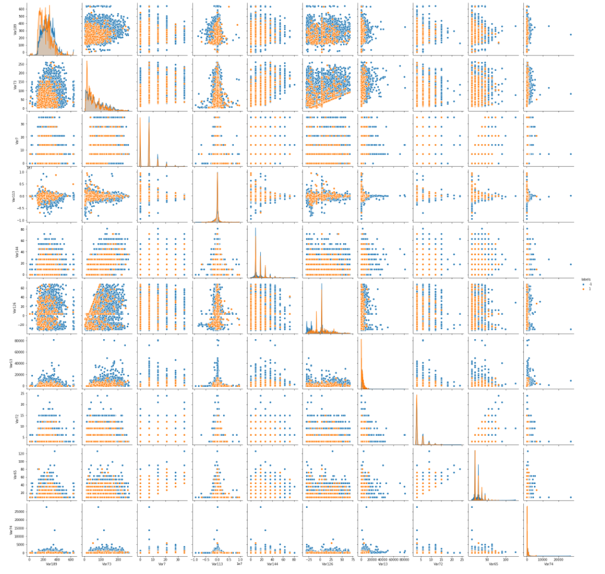

```python
Image('PairPlot.png')
```

Для некоторых признаков были обнаружены различия в распределениях плотностей в разрезе классов. Сильнее всего это проявилось для признаков Var189 И Var126. Было выдвинуто предположение, что эти признаки окажутся наиболее значимыми, из вещественных признаков, для будущей модели.

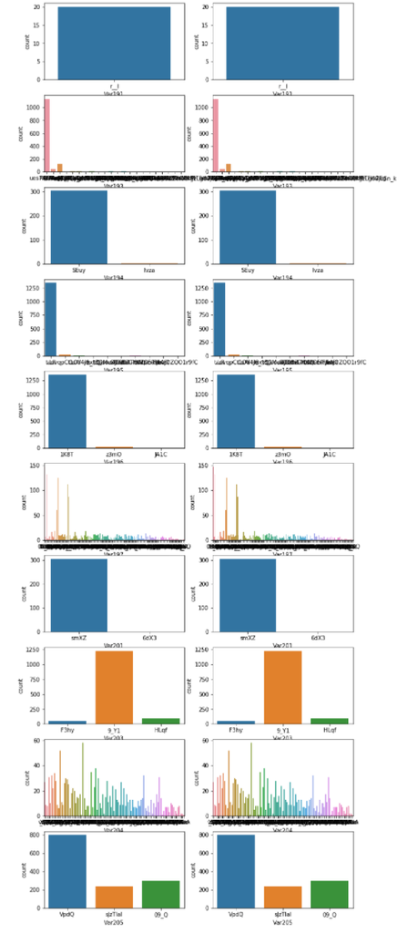

```python
Image('Histogram.png')
```

Из гистограмм для категориальных признаков в разрезе классов было установлено, что некоторые признаки содержат огромное количество категорий. Наличие таких признаков усложнило решение данной задачи.

### 3.2) Выбор метрики качества и способа ее оценки

В ходе описательного анализа данных был выявлен дисбаланс классов. Поэтому в качестве основной метрики была выбрана **ROC-AUC метрика**, так как она не зависит от баланса классов. В качестве дополнительных метрик были выбранны точность и полнота, потому что в данной задаче важно следить за ошибками false positive и false negative.

Качество построенных моделей оценивалось при помощи кросс-валидации со стратегией разбиения данных stratified k-fold с разбиением на 4 фолда. Данный подход позволил сохранить соотношение классов в обучающих и тестовых подвыборках.  
Также для итоговой оценки качества построенной модели от исходной выборки была отделенна отложенная выборка в размере 1/4 от исходной.

## 4) Построение baseline-решений

Для быстрой предварительной оценки качества, которое можно получить на имеющихся данных были построены baseline-модели. При предобработке данных в данном случае использовалось удаление константных признаков, заполнение пропусков среднимим значениями у вещественных и самыми популярными значениями у категориальных признаков. Далее для категориальных данных было использованно One-Hot кодирование.  
Были построены слудущие модели:

- **Логистическая регрессия**: ROC-AUC = 0.64
- **Случайный лес**: ROC-AUC = 0.67
- **Градиентный бустинг** (catboost): ROC-AUC = 0.64

При построении baseline-моделей была получена грубая оценка возможного качества, а также сделаны предположения о наиболее перспективных подходах при построении решения.

## 5) Построение основного решения

При построении основного решения упор делался на улучшение качества baseline-модели. Это было достигнуто за счет двух этапов: более качественная предобработка данных и подбор наиболее оптимальных параметров модели классификации для данной задачи.  
Изображенная ниже схема отражает процесс построения решения.

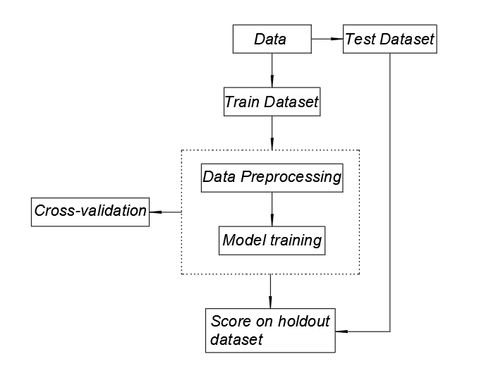

```python
Image('PipelineAlgorithm.png')
```

Предобработка данных и обучение модели классификации были вынесены в один pipeline (изображено на схеме прямоугольником со шриховыми линиями). То есть при каждом этапе обучения модели, сначала происходило разделение данных на обучение и на тест, все алгоритмы предобработки обучались на тренировочных данных, а при оценки качества тестовые данные предобрабатывались с помощью уже обученных алгоритмов. Это было сделано с целью избежания утечки данных и наиболее правдоподобных результатов при оценки качества модели на кросс-валидации.

**Предобработка данных** заключалась в следующем:

- Удаление константных признаков
- Заполнение пропусков у вещественных и категориальных признаков
- Кодирование категориальных данных с помощью OneHot encoder

**Лучшее качество** моделей на отложенной выборке, которое удалось достичь на данном этапе решения:

- **Случайный лес:** ROC-AUC = 0.7224
- **Градиентный бустинг:** ROC-AUC = 0.7566

В качестве итоговой модели на данном этапе был выбран Градиентный бустинг.

## 6) Соревнование на Kaggle

В ходе решения задания было приняно участие в соревновании на Kaggle: https://www.kaggle.com/c/telecom-clients-prediction2

Были получены следующие результаты:

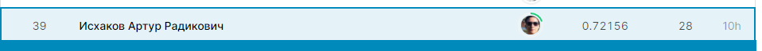

```python
Image('Result.png')
```

## 7) Эксперименты с моделью прогнозирования и построение финального решения

На данном этапе решения была проведена серия экспериментов как с предобработкой данных, так и с моделью классификации. Цель данного ряда экспериметов заключается в оптимизации и улучшении основного решения и построении финального решения.

**Эксперименты**, которые были сделаны:

- **Оценка количесва объектов** в выборке, необходимых для построения модели:

В ходе данного эксперимента, путем построения кривых обучения было установлено, что лучшее качество удается достичь, используя все объекты из выборки.

- Сравнение различных подходов для **борьбы с дисбалансом классов** в данных:

Среди различных подходов к измению весов объектов лучший результат показал подход на основе ручной балансировки весов на основании доли каждого класса в выборке.  
Были использованы различные методы сэмплирования (удаление объектов миноритарного класса). Но ни один из них не дал прироста в качесве.

- **Заполнение пропусков** в данных:

Лучшая стратегия заполнения пропусков, с точки зрения качества модели, у вещественных признаков - заполнение средними значениями, а у категориальных признаков - заполнение константными значениями.

- **Обработка категориальных признаков:**

В проведенном эксперименте лучшее качество на кросс-валидации показала стратегия обработки категориальных признаков на основе модели (catboost). Поэтому данный вариант является наиболее оптимальным с точки зрения качества.

Также была проведена оценка важности признаков для построенной модели.

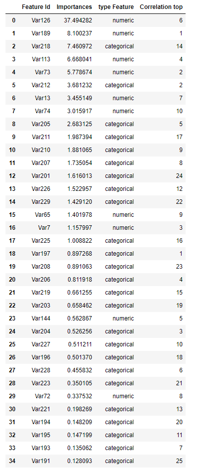

```python
Image('FeaturesImportance.png')
```

На основе данной таблицы можно заключить, что в топ 10 наиболее важных признаков в построенной модели преобладают вещественные признаки, а также признаки, которые имеют сильную корреляцию с целевой функцией.

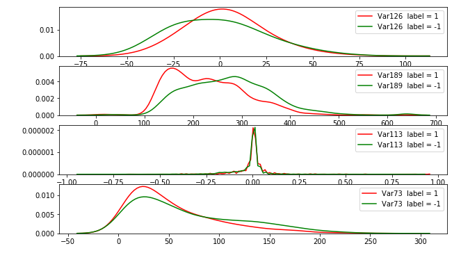

```python
Image('KDEPlot.png')
```

Плотности распредения в разрезе классов для первых 4 вещественных признаков наиболее важных для построенной модели. Здесь видны различия в распредлениях плотностей вещественных признаков по целевой функции, что также объясняет важность данных признаков для модели.

## 8) Финальное решение

По итогам проведенных экспериментов было построено финальное решение.  
**Финальное решение** состоит из:

**Преобразования данных:**

- **Удаление** константных признаков и категориальных признаков, вариация значений которых больше 300.
- **Заполнение** пропусков:
  - средними значениями у вещественных признаков
  - константными значениями у категориальных признаков
- **Отбор** признаков на основе **корреляции** с целевой функцией:
  - для вещественных признаков корреляция рассчитывается как разность математический ожиданий признака при условии класса "отток" и признака при условии класса "не отток".
  - для категориальных признаков корреляция рассчитывается с помощью коэффициента V крамера.

**Построение модели:**

- В качестве модели используется модель градиентного бустинга (**catboost**).
- Отдельно задаем, в качестве параметра модели, балансировку весов, на основе доли каждого класса в выборке.

На вход модели подаются 10 вещественных и 25 категориальных признаков, которые имеют наибольшее значение корреляции с целевой функцией.

**Итоговое качество** модели по метрике ROC_AUC:

- Среднее качество на кросс-валидации: 0.7292
- На отложенной выборке: 0.7693

## 9) Оценка эффекта от внедрения полученного решения

Была проведена оценка потенциального экономического эффекта от внедрения полученного решения. Для этого была построена простая **экономическая модель**.

**Параметры** экономической модели:

- денег в среднем приносит один пользователь: **5 условных единиц**.
- денег в среднем будет вложено в удержание одного пользователя: **2 условные единицы**.
- вероятность принятия пользователем предложения по удержанию: **0.75**
- количесво пользователей, которые будут участвовать в кампании по удержанию: **изменяется**

Без примения модели все пользователи класса "отток" покинут организацию.  
С применением модели пользователи ведут себя следующим образом:

- Верно отнесенные к классу "отток" останутся в компании с вероятностью 0.75
- Пользователи, на которых модель совершила ошибку false negative, т е совершила ложный пропуск пользователей с истинным классом "отток", покидают организацию.
- Пользователи, истинно отнесенные к классу "не отток", а также пользователи, ложно отнесенные к классу "отток" при их истинном классе "не отток" остаются в организации.

Модель классификации возвращает вероятности отнесения объектов к конкретному классу. С помощью изменения порога можно изменять отнесения объектов к классам.  
Перебор порогов и полученный доход.

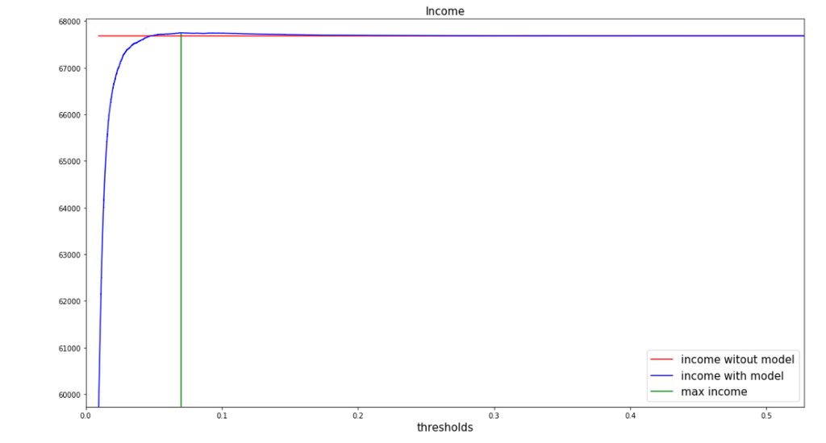

```python
Image('Income.png')
```

Посредством перебора удалось подобрать порог разделения для прибыльной кампании по удержанию.